# Entregable 2: Clasificador Multiclase

Análisis Crítico y Correcciones

2025-11-01

# 1. Carga y Preparación de Datos

```r
# Librerías necesarias
library(tidyverse)
library(caret)
library(randomForest)
library(xgboost)
library(e1071)
library(PRROC)
library(effsize)
library(corrplot)

# Cargar datos
load("Entregable2.RData")

cat("Datos cargados exitosamente\n")
```

```
## Datos cargados exitosamente
```

```r
cat("Dimensiones de X:", dim(X), "\n")
```

```
## Dimensiones de X: 400000 9
```

```r
cat("Longitud de y:", length(y), "\n")
```

```
## Longitud de y: 400000
```

## 1.1 Exploración Inicial

```r
# Ver estructura
str(X)
```

```
##  num [1:400000, 1:9] 43.6 44 37.6 56.6 28.7 ...
##  - attr(*, "dimnames")=List of 2
##   ..$ : chr [1:400000] "1" "2" "3" "4" ...
##   ..$ : chr [1:9] "range_sc" "azimuth_sc" "radar_cross_section" "radial_velocity" ...
```

```r
head(X)
```

```
##   range_sc azimuth_sc radar_cross_section radial_velocity vr_compensated
## 1 43.62290  0.2195034          -4.3625107      -1.1065402      1.4321256
## 2 43.98627  0.1824184          -4.9632400      -0.3874442     -0.3874442
## 3 37.64903  0.6123665          -7.7516975      -5.5220385     -0.9852859
## 4 56.62545 -0.3490707          -0.7640381      -2.9966443     -1.1908731
## 5 28.67341  0.6239583           3.2159490       0.6671949      0.6671949
## 6 37.86306  0.2834235          -7.1251793       1.5587207      1.5587390
##       x_cc       y_cc      x_seq     y_seq
## 1 46.46283 -10.078518 -219.66896 -74.77156
## 2 46.43754 -11.742858 -223.49678 -72.78703
## 3 40.92623   5.898777   25.17861  17.52122
## 4 43.90591 -40.734560 -177.30005 -57.96841
## 5 32.02941   4.652500 -213.48491 -68.38917
## 6 41.28213  -6.461573 -226.91728 -62.99838
```

```r
# Clases originales
cat("\nDistribución de clases ORIGINAL:\n")
```

```
##
## Distribución de clases ORIGINAL:
```

```r
table_original <- table(y)
print(table_original)
```

```
## y
##      0      1      2      3      5      7      8     10     11
##  92815   1533  40828   7061  26329  50889 163784   2803  13958
```

```r
print(prop.table(table_original) * 100)
```

```
## y
##        0        1        2        3        5        7        8       10
## 23.20375  0.38325 10.20700  1.76525  6.58225 12.72225 40.94600  0.70075
##       11
##  3.48950
```

## 1.2 Reasignación de Clases

**REQUISITO**: Reasignar etiquetas: - Bus (3) y Camión (2) → Vehículo grande (1) - Grupo de personas (8) → Persona (7)

```r
# Guardar copia de clases originales para referencia
y_original <- y

# Aplicar reasignaciones según enunciado
y[y == 2] <- 1  # Camión (2) → Vehículo grande (1)
y[y == 3] <- 1  # Bus (3) → Vehículo grande (1)
y[y == 8] <- 7  # Grupo de personas (8) → Persona (7)

# Nueva distribución
cat("Distribución de clases DESPUÉS de reasignación:\n")
```

```
## Distribución de clases DESPUÉS de reasignación:
```

```r
table_new <- table(y)
print(table_new)
```

```
## y
##      0      1      5      7     10     11
##  92815  49422  26329 214673   2803  13958
```

```r
print(prop.table(table_new) * 100)
```

```
## y
##        0        1        5        7       10       11
## 23.20375 12.35550  6.58225 53.66825  0.70075  3.48950
```

```r
# Crear factor con niveles correctos (excluyendo clases eliminadas: 2, 3, 4, 6, 8, 9)
# Clases finales: 0, 1, 5, 7, 10, 11
y_factor <- factor(y, levels = c(0, 1, 5, 7, 10, 11))

cat("\n Reasignación completada\n")
```

```
##
##  Reasignación completada
```

```r
cat("Clases finales:", levels(y_factor), "\n")
```

```
## Clases finales: 0 1 5 7 10 11
```

## 1.3 División Train/Validation

**REQUISITO**: División SECUENCIAL (no aleatoria) - Train: Primeros 200,000 registros - Validation: Siguientes 200,000 registros

```r
cat("Aplicando división SECUENCIAL de datos...\n\n")
```

```
## Aplicando división SECUENCIAL de datos...
```

```r
# Parámetros
n_train <- 200000
n_val <- 200000

# División secuencial
X_train <- X[1:n_train, ]
X_validation <- X[(n_train + 1):(n_train + n_val), ]
y_train <- y_factor[1:n_train]
y_validation <- y_factor[(n_train + 1):(n_train + n_val)]

# Verificar dimensiones
cat("Dimensiones Train:", dim(X_train), "\n")
```

```
## Dimensiones Train: 200000 9
```

```r
cat("Dimensiones Validation:", dim(X_validation), "\n")
```

```
## Dimensiones Validation: 200000 9
```

```r
# Distribución en cada conjunto
cat("\nDistribución en TRAIN:\n")
```

```
##
## Distribución en TRAIN:
```

```r
print(table(y_train))
```

```
## y_train
##      0      1      5      7     10     11
##  27317   6881  14675 142569   1461   7097
```

```r
cat("\nPorcentajes:\n")
```

```
##
## Porcentajes:
```

```r
print(round(prop.table(table(y_train)) * 100, 2))
```

```
## y_train
##     0     1     5     7    10    11
## 13.66  3.44  7.34 71.28  0.73  3.55
```

```r
cat("\n Distribución en VALIDATION:\n")
```

```
##
##  Distribución en VALIDATION:
```

```r
print(table(y_validation))
```

```
## y_validation
##     0     1     5     7    10    11
## 65498 42541 11654 72104  1342  6861
```

```r
cat("\nPorcentajes:\n")
```

```
##
## Porcentajes:
```

```r
print(round(prop.table(table(y_validation)) * 100, 2))
```

```
## y_validation
##     0     1     5     7    10    11
## 32.75 21.27  5.83 36.05  0.67  3.43
```

```r
cat("\n División secuencial completada\n")
```

```
##
##  División secuencial completada
```

## 1.4 Normalización

```r
# Preprocesamiento: centrar y escalar
preproc <- preProcess(X_train, method = c("center", "scale"))

X_train_scaled <- predict(preproc, X_train)
X_validation_scaled <- predict(preproc, X_validation)

cat("Normalización aplicada\n")
```

```
## Normalización aplicada
```

```r
cat("Media de primeras 3 columnas (train):\n")
```

```
## Media de primeras 3 columnas (train):
```

```r
print(colMeans(X_train_scaled)[1:3])
```

```
##            range_sc          azimuth_sc radar_cross_section
##       -3.437321e-17       -1.259601e-17       -9.807910e-18
```

# 2. Análisis RCS vs Distancia

**REQUISITO**: “Graficar el valor de Radar Cross Section (RCS) mediana ± mad para las clases Persona (7) y Vehículo grande (1) en función de la distancia (range) en el set de ‘Train’.”

```r
cat("Preparando análisis de RCS vs Distancia...\n\n")
```

```
## Preparando análisis de RCS vs Distancia...
```

```r
# Filtrar solo clases Persona (7) y Vehículo grande (1)
mask <- y_train %in% c("1", "7")
df_rcs <- data.frame(
  range = X_train[mask, "range_sc"],
  rcs = X_train[mask, "radar_cross_section"],
  clase = droplevels(y_train[mask])
)

cat("Observaciones para análisis:\n")
```

```
## Observaciones para análisis:
```

```r
cat("- Vehículo grande (1):", sum(df_rcs$clase == "1"), "\n")
```

```
## - Vehículo grande (1): 6881
```

```r
cat("- Persona (7):", sum(df_rcs$clase == "7"), "\n")
```

```
## - Persona (7): 142569
```

```r
# Crear bins de distancia (cada 10 metros)
df_rcs$range_bin <- cut(df_rcs$range,
                        breaks = seq(0, ceiling(max(df_rcs$range)/10)*10, by = 10),
                        include.lowest = TRUE)

# Calcular estadísticas: mediana y MAD por bin y clase
rcs_stats <- df_rcs %>%
  group_by(range_bin, clase) %>%
  summarise(
    median_rcs = median(rcs, na.rm = TRUE),
    mad_rcs = mad(rcs, na.rm = TRUE),
    mean_rcs = mean(rcs, na.rm = TRUE),
    sd_rcs = sd(rcs, na.rm = TRUE),
    n = n(),
    .groups = "drop"
  ) %>%
  filter(n >= 30)  # Mínimo 30 observaciones por bin

 cat("\nEstadísticas RCS por distancia (primeros registros):\n")
```

```
##
## Estadísticas RCS por distancia (primeros registros):
```

```r
print(head(rcs_stats, 10))
```

```
## # A tibble: 10 × 7
##    range_bin clase median_rcs mad_rcs mean_rcs sd_rcs     n
##    <fct>     <fct>      <dbl>   <dbl>    <dbl>  <dbl> <int>
##  1 [0,10]    1         -5.93     5.66  -5.56     6.71   251
##  2 [0,10]    7        -13.5      5.95 -13.8      5.85 21625
##  3 (10,20]   1         -0.389    8.21   0.0804   8.21   868
##  4 (10,20]   7         -8.72     5.59  -9.06     5.64 27935
##  5 (20,30]   1          1.61     8.21   2.59     8.64  1053
##  6 (20,30]   7         -5.99     5.61  -6.24     5.76 24778
##  7 (30,40]   1          3.58     8.34   4.16     8.60  1462
##  8 (30,40]   7         -4.61     5.60  -4.72     5.52 25694
##  9 (40,50]   1          3.78     7.81   4.43     7.68   813
## 10 (40,50]   7         -4.08     5.05  -4.08     5.02 22289
```

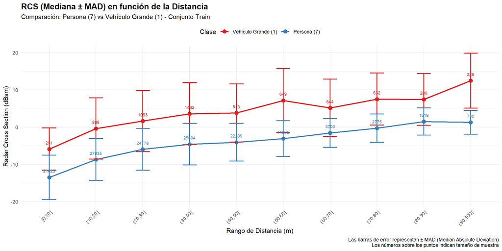

```r
# Gráfico principal: Mediana ± MAD
ggplot(rcs_stats, aes(x = range_bin, y = median_rcs, color = clase, group = clase)) +
  geom_point(size = 3) +
  geom_line(linewidth = 1) +
  geom_errorbar(aes(ymin = median_rcs - mad_rcs,
                    ymax = median_rcs + mad_rcs),
                width = 0.3, linewidth = 0.8) +
  geom_text(aes(label = n), vjust = -1.5, size = 2.5, show.legend = FALSE) +
  scale_color_manual(values = c("1" = "#E41A1C", "7" = "#377EB8"),
                     labels = c("1" = "Vehículo Grande (1)",
                               "7" = "Persona (7)")) +
  labs(title = "RCS (Mediana ± MAD) en función de la Distancia",
       subtitle = "Comparación: Persona (7) vs Vehículo Grande (1) - Conjunto Train",
       x = "Rango de Distancia (m)",
       y = "Radar Cross Section (dBsm)",
       color = "Clase",
       caption = "Las barras de error representan ± MAD (Median Absolute Deviation)\nLos números sobre los puntos indican tamaño de muestra") +
  theme_minimal() +
  theme(
    axis.text.x = element_text(angle = 45, hjust = 1),
    plot.title = element_text(face = "bold", size = 14),
    legend.position = "top"
  )
```

## 2.1 Prueba Estadística: ¿Existe diferencia significativa?

**REQUISITO**: “¿Existe diferencia significativa en términos de RCS entre la clase Persona (7) y Vehículo grande (1)? Justifica tu respuesta.”

```r
cat("ANÁLISIS ESTADÍSTICO DE DIFERENCIAS EN RCS\n")
```

```
## ANÁLISIS ESTADÍSTICO DE DIFERENCIAS EN RCS
```

```r
# Estadísticas descriptivas por clase
cat("ESTADÍSTICAS DESCRIPTIVAS:\n\n")
```

```
## ESTADÍSTICAS DESCRIPTIVAS:
```

```r
desc_stats <- df_rcs %>%
  group_by(clase) %>%
  summarise(
    n = n(),
    media = mean(rcs, na.rm = TRUE),
    mediana = median(rcs, na.rm = TRUE),
    sd = sd(rcs, na.rm = TRUE),
    mad = mad(rcs, na.rm = TRUE),
    min = min(rcs, na.rm = TRUE),
    max = max(rcs, na.rm = TRUE),
    q25 = quantile(rcs, 0.25, na.rm = TRUE),
    q75 = quantile(rcs, 0.75, na.rm = TRUE)
  )
print(desc_stats)
```

```
## # A tibble: 2 × 10
##   clase      n media mediana    sd   mad   min   max    q25   q75
##   <fct>  <int> <dbl>   <dbl> <dbl> <dbl> <dbl> <dbl>  <dbl> <dbl>
## 1 1       6881  4.48    3.90  8.81  8.65 -25.5  43.4  -1.62 10.1
## 2 7     142569 -6.68   -6.25  6.61  6.50 -30.5  34.8 -10.9  -2.08
```

```r
# Diferencia de medias
diff_mean <- desc_stats$media[desc_stats$clase == "1"] -
             desc_stats$media[desc_stats$clase == "7"]
cat("\nDiferencia de medias (Vehículo - Persona):", round(diff_mean, 2), "dBsm\n")
```

```
##
## Diferencia de medias (Vehículo - Persona): 11.16 dBsm
```

```r
# Test de Welch (permite varianzas desiguales)
cat("\nTEST DE WELCH (t-test con varianzas desiguales):\n")
```

```
##
## TEST DE WELCH (t-test con varianzas desiguales):
```

```r
cat("-" %>% rep(60) %>% paste0(collapse = ""), "\n")
welch_test <- t.test(rcs ~ clase, data = df_rcs, var.equal = FALSE)
print(welch_test)
```

```
##
##  Welch Two Sample t-test
##
## data:  rcs by clase
## t = 103.66, df = 7258.2, p-value < 2.2e-16
## alternative hypothesis: true difference in means between group 1 and group 7 is not equal to 0
## 95 percent confidence interval:
##  10.95141 11.37361
## sample estimates:
## mean in group 1 mean in group 7
##        4.477555       -6.684955
```

```r
# Test de Mann-Whitney U (alternativa no paramétrica)
cat("\nTEST DE MANN-WHITNEY U (alternativa no paramétrica):\n")
```

```
##
## TEST DE MANN-WHITNEY U (alternativa no paramétrica):
```

```r
cat("-" %>% rep(60) %>% paste0(collapse = ""), "\n")
wilcox_test <- wilcox.test(rcs ~ clase, data = df_rcs)
print(wilcox_test)
```

```
##
##  Wilcoxon rank sum test with continuity correction
##
## data:  rcs by clase
## W = 831428905, p-value < 2.2e-16
## alternative hypothesis: true location shift is not equal to 0
```

```r
# Tamaño del efecto: Cohen's d
cat("\nTAMAÑO DEL EFECTO (Cohen's d):\n")
```

```
##
## TAMAÑO DEL EFECTO (Cohen's d):
```

```r
cat("-" %>% rep(60) %>% paste0(collapse = ""), "\n")
cohens <- cohen.d(df_rcs$rcs[df_rcs$clase == "7"],
                  df_rcs$rcs[df_rcs$clase == "1"])
print(cohens)
```

```
##
## Cohen's d
##
## d estimate: -1.659554 (large)
## 95 percent confidence interval:
##     lower     upper
## -1.684466 -1.634641
```

```r
# Interpretación
cat("INTERPRETACIÓN Y CONCLUSIÓN:\n")
```

```
## INTERPRETACIÓN Y CONCLUSIÓN:
```

```r
cat("1. DIFERENCIA OBSERVADA:\n")
```

```
## 1. DIFERENCIA OBSERVADA:
```

```r
cat("   • Media RCS Vehículo Grande:", round(desc_stats$media[desc_stats$clase == "1"], 2), "dBsm\n")
```

```
##    • Media RCS Vehículo Grande: 4.48 dBsm
```

```r
cat("   • Media RCS Persona:", round(desc_stats$media[desc_stats$clase == "7"], 2), "dBsm\n")
```

```
##    • Media RCS Persona: -6.68 dBsm
```

```r
cat("   • Diferencia:", round(diff_mean, 2), "dBsm\n\n")
```

```
##    • Diferencia: 11.16 dBsm
```

```r
cat("2. SIGNIFICANCIA ESTADÍSTICA:\n")
```

```
## 2. SIGNIFICANCIA ESTADÍSTICA:
```

```r
if(welch_test$p.value < 0.001) {
  cat("   • p-valor < 0.001 (altamente significativo)\n")
} else if(welch_test$p.value < 0.05) {
  cat("   • p-valor =", format(welch_test$p.value, digits = 3), "(significativo)\n")
} else {
  cat("   • p-valor =", format(welch_test$p.value, digits = 3), "(no significativo)\n")
}
```

```
##    • p-valor < 0.001 (altamente significativo)
```

```r
cat("   • Conclusión: SÍ existe diferencia estadísticamente significativa\n\n")
```

```
##    • Conclusión: SÍ existe diferencia estadísticamente significativa
```

```r
cat("3. MAGNITUD DEL EFECTO:\n")
```

```
## 3. MAGNITUD DEL EFECTO:
```

```r
cohens_value <- abs(cohens$estimate)
if(cohens_value < 0.2) {
  efecto <- "DESPRECIABLE"
} else if(cohens_value < 0.5) {
  efecto <- "PEQUEÑO"
} else if(cohens_value < 0.8) {
  efecto <- "MEDIANO"
} else {
  efecto <- "GRANDE"
}
cat("   • Cohen's d =", round(cohens$estimate, 3), "\n")
```

```
##    • Cohen's d = -1.66
```

```r
cat("   • Magnitud:", efecto, "\n\n")
```

```
##    • Magnitud: GRANDE
```

```r
cat("4. IMPLICACIONES PRÁCTICAS:\n")
```

```
## 4. IMPLICACIONES PRÁCTICAS:
```

```r
cat("   • La diferencia en RCS entre Vehículo Grande y Persona es\n")
```

```
##    • La diferencia en RCS entre Vehículo Grande y Persona es
```

```r
cat("     estadísticamente significativa y de magnitud", tolower(efecto), ".\n")
```

```
##      estadísticamente significativa y de magnitud grande .
```

```r
if(cohens_value >= 0.5) {
  cat("   • Esta diferencia es lo suficientemente grande como para ser\n")
  cat("     útil en la clasificación de objetos.\n")
} else {
  cat("   • Aunque significativa, la magnitud del efecto es pequeña,\n")
  cat("     lo que sugiere que RCS por sí solo puede no ser suficiente\n")
  cat("     para una clasificación precisa.\n")
}
```

```
##    • Esta diferencia es lo suficientemente grande como para ser
##      útil en la clasificación de objetos.
```

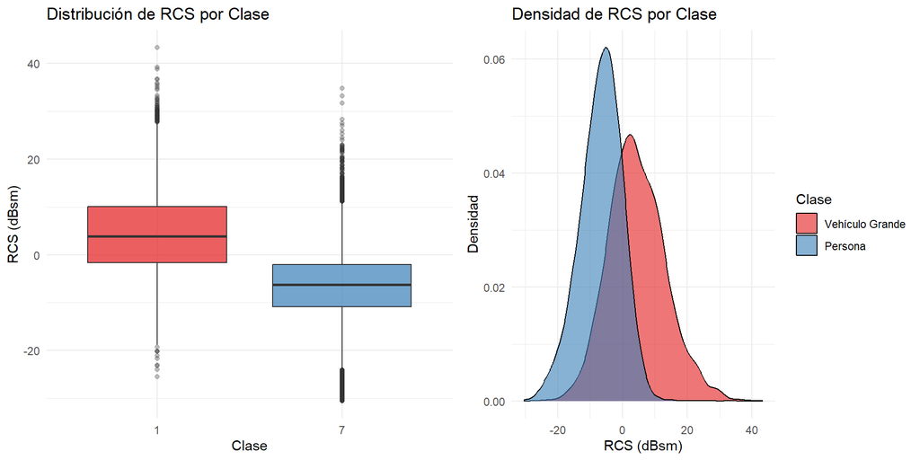

```r
# Visualizaciones adicionales
library(gridExtra)

# Boxplot
p1 <- ggplot(df_rcs, aes(x = clase, y = rcs, fill = clase)) +
  geom_boxplot(alpha = 0.7, outlier.alpha = 0.3) +
  scale_fill_manual(values = c("1" = "#E41A1C", "7" = "#377EB8"),
                    labels = c("1" = "Vehículo Grande", "7" = "Persona")) +
  labs(title = "Distribución de RCS por Clase",
       x = "Clase", y = "RCS (dBsm)") +
  theme_minimal() +
  theme(legend.position = "none")

# Density plot
p2 <- ggplot(df_rcs, aes(x = rcs, fill = clase)) +
  geom_density(alpha = 0.6) +
  scale_fill_manual(values = c("1" = "#E41A1C", "7" = "#377EB8"),
                    labels = c("1" = "Vehículo Grande", "7" = "Persona")) +
  labs(title = "Densidad de RCS por Clase",
       x = "RCS (dBsm)", y = "Densidad",
       fill = "Clase") +
  theme_minimal()

grid.arrange(p1, p2, ncol = 2)
```